# Chapter 8

# Chapter 8

```r
knitr::opts_chunk$set(cache = TRUE,autodep = TRUE)
library(rethinking)
```

```r
library(ggplot2)
library(reshape2)
```

## 8E1

The simple Metropolis algorhithim requires that the proposal distribution be symmetric

## 8E2

Gibbs sampling achieves its efficiency by using conjugate priors. Maybe you don’t want to use conjugate priors. Also becomes very ineffecient with large numbers of parameters.

## 8E3

HMC requires cannot handle discrete parameters. This is because it is sampling the probability space by gliding through it, and it is unclear how to glide between discrete points.

## 8E4

Because there is autocorrelation in MCMC chains samples are not independent and the effective number of samples is reduced. Neff estimates this.

## 8E5

Rhat should approach 1 (from above)

## 8E6

Should stabilize

## 8M1

Re-estimate the terrain ruggedness model from the chapter but now using a uniform prior and an exponential prior for sigma. Any difference in postieror distribition?

```r
library(rethinking)
data(rugged)
d <- rugged
d$log_gdp <- log(d$rgdppc_2000)
dd <- d[ complete.cases(d$rgdppc_2000) , ]

dd.trim <- dd[ , c("log_gdp","rugged","cont_africa") ]

m8m1A.stan <- map2stan(
  alist(
    log_gdp ~ dnorm( mu , sigma ) ,
    mu <- a + bR*rugged + bA*cont_africa + bAR*rugged*cont_africa ,
    a ~ dnorm(0,100),
    bR ~ dnorm(0,10),
    bA ~ dnorm(0,10),
    bAR ~ dnorm(0,10),
    sigma ~ dcauchy(0,2)
  ), data=dd.trim )
```

[output not shown]

[output not shown]

[output not shown]

[output not shown]

[output not shown]

[output not shown]

[output not shown]

```
## Computing WAIC
```

```
## Constructing posterior predictions
```

```
## [ 100 / 1000 ]
[ 200 / 1000 ]
[ 300 / 1000 ]
[ 400 / 1000 ]
[ 500 / 1000 ]
[ 600 / 1000 ]
[ 700 / 1000 ]
[ 800 / 1000 ]
[ 900 / 1000 ]
[ 1000 / 1000 ]
```

```r
m8m1_dunif.stan <- map2stan(
  alist(
    log_gdp ~ dnorm( mu , sigma ) ,
    mu <- a + bR*rugged + bA*cont_africa + bAR*rugged*cont_africa ,
    a ~ dnorm(0,100),
    bR ~ dnorm(0,10),
    bA ~ dnorm(0,10),
    bAR ~ dnorm(0,10),
    sigma ~ dunif(0,10)
  ), data=dd.trim )
```

[output not shown]

```
## Computing WAIC
## Constructing posterior predictions
```

```
## [ 100 / 1000 ]
[ 200 / 1000 ]
[ 300 / 1000 ]
[ 400 / 1000 ]
[ 500 / 1000 ]
[ 600 / 1000 ]
[ 700 / 1000 ]
[ 800 / 1000 ]
[ 900 / 1000 ]
[ 1000 / 1000 ]
```

```r
m8m1_exp.stan <- map2stan(
  alist(
    log_gdp ~ dnorm( mu , sigma ) ,
    mu <- a + bR*rugged + bA*cont_africa + bAR*rugged*cont_africa ,
    a ~ dnorm(0,100),
    bR ~ dnorm(0,10),
    bA ~ dnorm(0,10),
    bAR ~ dnorm(0,10),
    sigma ~ dexp(1)
  ), data=dd.trim )
```

[output not shown]

```
## Computing WAIC
## Constructing posterior predictions
```

```
## [ 100 / 1000 ]
[ 200 / 1000 ]
[ 300 / 1000 ]
[ 400 / 1000 ]
[ 500 / 1000 ]
[ 600 / 1000 ]
[ 700 / 1000 ]
[ 800 / 1000 ]
[ 900 / 1000 ]
[ 1000 / 1000 ]
```

```r
precis(m8m1A.stan)
```

```
##        Mean StdDev lower 0.89 upper 0.89 n_eff Rhat
## a      9.23   0.13       8.99       9.42   208 1.01
## bR    -0.21   0.07      -0.32      -0.08   217 1.01
## bA    -1.95   0.21      -2.28      -1.60   193 1.00
## bAR    0.40   0.13       0.19       0.59   268 1.00
## sigma  0.95   0.05       0.87       1.03   672 1.01
```

```r
precis(m8m1_dunif.stan)
```

```
##        Mean StdDev lower 0.89 upper 0.89 n_eff Rhat
## a      9.22   0.13       9.02       9.43   400 1.00
## bR    -0.20   0.07      -0.30      -0.07   431 1.00
## bA    -1.95   0.22      -2.28      -1.60   395 1.01
## bAR    0.39   0.12       0.21       0.59   382 1.01
## sigma  0.95   0.05       0.87       1.02   720 1.00
```

```r
precis(m8m1_exp.stan)
```

```
##        Mean StdDev lower 0.89 upper 0.89 n_eff Rhat
## a      9.23   0.14       8.99       9.44   336    1
## bR    -0.20   0.08      -0.32      -0.09   308    1
## bA    -1.94   0.23      -2.28      -1.57   340    1
## bAR    0.39   0.13       0.19       0.60   373    1
## sigma  0.95   0.05       0.87       1.02   625    1
```

```r
sigmas <- data.frame(
  cauchy=extract.samples(m8m1A.stan)$sigma,
  unif=extract.samples(m8m1_dunif.stan)$sigma,
  exp=extract.samples(m8m1_exp.stan)$sigma)

sigmas.m <- melt(sigmas,variable.name="prior.function",value.name="sigma")
# summary(sigmas.m)
dim(sigmas.m$sigma) <- 3000 #strange that I need to do this!!
summary(sigmas.m)
```

```
##  prior.function     sigma
##  cauchy:1000    Min.   :0.7817
##  unif  :1000    1st Qu.:0.9167
##  exp   :1000    Median :0.9482
##                 Mean   :0.9503
##                 3rd Qu.:0.9805
##                 Max.   :1.1390
```

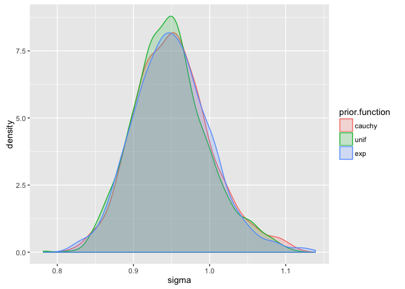

```r
pl <- ggplot(sigmas.m, aes(sigma,color=prior.function,fill=prior.function))
pl + geom_density(alpha=.2)
```

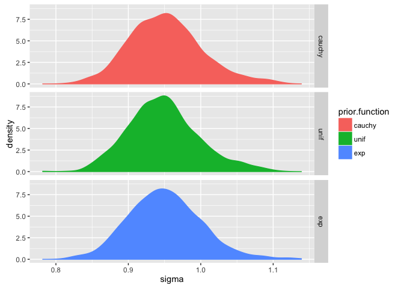

```r
pl + geom_density() + facet_grid(prior.function ~ .)
```

Look very similar. I *assume* the differences are due to sampling.

## 8M2 Use smaller values of scaling parameter for sigma prior to see how that changes things…

### First the cauchy model

What happends to cauchy distribution at different scales?

```r
x <- seq(-10,10,.1)
scale <- c(2,1,.5,.2)
cauchy.dist <- as.data.frame(cbind(x,sapply(scale,function(s) dcauchy(x,location=0,scale = s))))
colnames(cauchy.dist)[2:5] <- as.character(scale)
head(cauchy.dist)
```

```
##       x           2           1         0.5          0.2
## 1 -10.0 0.006121344 0.003151583 0.001587580 0.0006363652
## 2  -9.9 0.006240758 0.003214927 0.001619733 0.0006492807
## 3  -9.8 0.006363652 0.003280193 0.001652871 0.0006625934
## 4  -9.7 0.006490160 0.003347459 0.001687036 0.0006763197
## 5  -9.6 0.006620422 0.003416809 0.001722270 0.0006904770
## 6  -9.5 0.006754586 0.003488328 0.001758618 0.0007050834
```

```r
cauchy.dist.m <- melt(cauchy.dist,id.vars="x",variable.name="scale.value",value.name="y")
head(cauchy.dist.m)
```

```
##       x scale.value           y
## 1 -10.0           2 0.006121344
## 2  -9.9           2 0.006240758
## 3  -9.8           2 0.006363652
## 4  -9.7           2 0.006490160
## 5  -9.6           2 0.006620422
## 6  -9.5           2 0.006754586
```

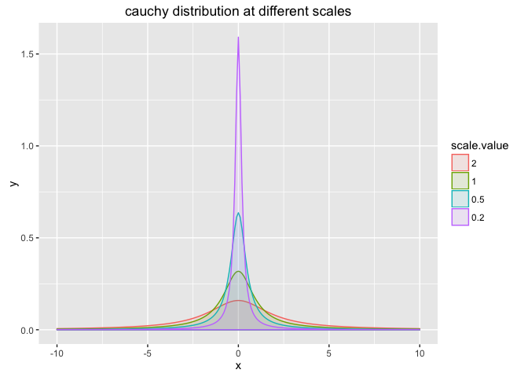

```r
pl <- ggplot(cauchy.dist.m,aes(x=x,y=y,fill=scale.value,color=scale.value))
pl <- pl + geom_density(stat="identity",alpha=0.1)
pl + ggtitle("cauchy distribution at different scales")
```

What happends to exp distribution at different rates?

```r
x <- seq(-10,10,.1)
rate <- c(2,1,.5,.2)
exp.dist <- as.data.frame(cbind(x,sapply(rate,function(r) dexp(x,rate = r))))
colnames(exp.dist)[2:5] <- as.character(rate)
head(exp.dist)
```

```
##       x 2 1 0.5 0.2
## 1 -10.0 0 0   0   0
## 2  -9.9 0 0   0   0
## 3  -9.8 0 0   0   0
## 4  -9.7 0 0   0   0
## 5  -9.6 0 0   0   0
## 6  -9.5 0 0   0   0
```

```r
exp.dist.m <- melt(exp.dist,id.vars="x",variable.name="rate.value",value.name="y")
head(exp.dist.m)
```

```
##       x rate.value y
## 1 -10.0          2 0
## 2  -9.9          2 0
## 3  -9.8          2 0
## 4  -9.7          2 0
## 5  -9.6          2 0
## 6  -9.5          2 0
```

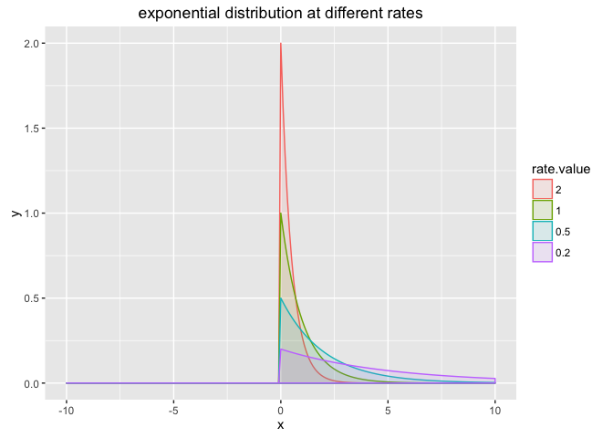

```r
pl <- ggplot(exp.dist.m,aes(x=x,y=y,fill=rate.value,color=rate.value))
pl <- pl + geom_density(stat="identity",alpha=0.1)
pl + ggtitle("exponential distribution at different rates")
```

Fit a series of cauchy models with smaller scales

```r
m8M2.stan.cauchy2 <- map2stan(
  alist(
    log_gdp ~ dnorm( mu , sigma ) ,
    mu <- a + bR*rugged + bA*cont_africa + bAR*rugged*cont_africa ,
    a ~ dnorm(0,100),
    bR ~ dnorm(0,10),
    bA ~ dnorm(0,10),
    bAR ~ dnorm(0,10),
    sigma ~ dcauchy(0,2)
  ), data=dd.trim )
```

[output not shown]

```
## Computing WAIC
```

```
## Constructing posterior predictions
```

```
## [ 100 / 1000 ]
[ 200 / 1000 ]
[ 300 / 1000 ]
[ 400 / 1000 ]
[ 500 / 1000 ]
[ 600 / 1000 ]
[ 700 / 1000 ]
[ 800 / 1000 ]
[ 900 / 1000 ]
[ 1000 / 1000 ]
```

```r
m8M2.stan.cauchy1 <- map2stan(
  alist(
    log_gdp ~ dnorm( mu , sigma ) ,
    mu <- a + bR*rugged + bA*cont_africa + bAR*rugged*cont_africa ,
    a ~ dnorm(0,100),
    bR ~ dnorm(0,10),
    bA ~ dnorm(0,10),
    bAR ~ dnorm(0,10),
    sigma ~ dcauchy(0,1)
  ), data=dd.trim )
```

[output not shown]

```
## Computing WAIC
## Constructing posterior predictions
```

```
## [ 100 / 1000 ]
[ 200 / 1000 ]
[ 300 / 1000 ]
[ 400 / 1000 ]
[ 500 / 1000 ]
[ 600 / 1000 ]
[ 700 / 1000 ]
[ 800 / 1000 ]
[ 900 / 1000 ]
[ 1000 / 1000 ]
```

```r
m8M2.stan.cauchy.5 <- map2stan(
  alist(
    log_gdp ~ dnorm( mu , sigma ) ,
    mu <- a + bR*rugged + bA*cont_africa + bAR*rugged*cont_africa ,
    a ~ dnorm(0,100),
    bR ~ dnorm(0,10),
    bA ~ dnorm(0,10),
    bAR ~ dnorm(0,10),
    sigma ~ dcauchy(0,.5)
  ), data=dd.trim )
```

[output not shown]

```
## Computing WAIC
## Constructing posterior predictions
```

```
## [ 100 / 1000 ]
[ 200 / 1000 ]
[ 300 / 1000 ]
[ 400 / 1000 ]
[ 500 / 1000 ]
[ 600 / 1000 ]
[ 700 / 1000 ]
[ 800 / 1000 ]
[ 900 / 1000 ]
[ 1000 / 1000 ]
```

```r
m8M2.stan.cauchy.2 <- map2stan(
  alist(
    log_gdp ~ dnorm( mu , sigma ) ,
    mu <- a + bR*rugged + bA*cont_africa + bAR*rugged*cont_africa ,
    a ~ dnorm(0,100),
    bR ~ dnorm(0,10),
    bA ~ dnorm(0,10),
    bAR ~ dnorm(0,10),
    sigma ~ dcauchy(0,.2)
  ), data=dd.trim )
```

[output not shown]

```
## Computing WAIC
## Constructing posterior predictions
```

```
## [ 100 / 1000 ]
[ 200 / 1000 ]
[ 300 / 1000 ]
[ 400 / 1000 ]
[ 500 / 1000 ]
[ 600 / 1000 ]
[ 700 / 1000 ]
[ 800 / 1000 ]
[ 900 / 1000 ]
[ 1000 / 1000 ]
```

look at posteriors

```r
precis(m8M2.stan.cauchy2)
```

```
##        Mean StdDev lower 0.89 upper 0.89 n_eff Rhat
## a      9.23   0.14       9.02       9.46   445    1
## bR    -0.21   0.07      -0.34      -0.10   440    1
## bA    -1.96   0.23      -2.36      -1.63   483    1
## bAR    0.40   0.13       0.19       0.59   480    1
## sigma  0.95   0.05       0.88       1.05   715    1
```

```r
precis(m8M2.stan.cauchy1)
```

```
##        Mean StdDev lower 0.89 upper 0.89 n_eff Rhat
## a      9.22   0.14       9.01       9.44   329 1.00
## bR    -0.20   0.08      -0.33      -0.07   317 1.00
## bA    -1.95   0.22      -2.32      -1.62   408 1.01
## bAR    0.39   0.13       0.19       0.60   379 1.00
## sigma  0.95   0.05       0.88       1.04   809 1.00
```

```r
precis(m8M2.stan.cauchy.5)
```

```
##        Mean StdDev lower 0.89 upper 0.89 n_eff Rhat
## a      9.23   0.13       9.02       9.43   381    1
## bR    -0.21   0.07      -0.32      -0.09   377    1
## bA    -1.96   0.22      -2.30      -1.62   373    1
## bAR    0.40   0.12       0.21       0.60   389    1
## sigma  0.95   0.05       0.87       1.02   751    1
```

```r
precis(m8M2.stan.cauchy.2)
```

```
##        Mean StdDev lower 0.89 upper 0.89 n_eff Rhat
## a      9.23   0.14       9.04       9.46   382    1
## bR    -0.21   0.08      -0.33      -0.08   336    1
## bA    -1.96   0.22      -2.32      -1.62   438    1
## bAR    0.40   0.14       0.19       0.62   404    1
## sigma  0.95   0.05       0.87       1.04   484    1
```

plot posteriors

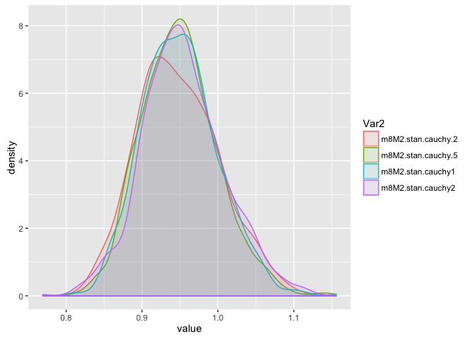

```r
fits <- ls(pattern="m8M2.stan.cauch")
sigmas <- sapply(fits, function(x) extract.samples(get(x))$sigma)
colnames(sigmas) <- fits
sigmas.m <- melt(sigmas)
pl <- ggplot(sigmas.m,aes(x=value,color=Var2,fill=Var2))
pl <- pl + geom_density(alpha=0.1)
pl
```

exp models with smaller scales:

```r
m8M2.stan.exp1 <- map2stan(
  alist(
    log_gdp ~ dnorm( mu , sigma ) ,
    mu <- a + bR*rugged + bA*cont_africa + bAR*rugged*cont_africa ,
    a ~ dnorm(0,100),
    bR ~ dnorm(0,10),
    bA ~ dnorm(0,10),
    bAR ~ dnorm(0,10),
    sigma ~ dexp(1)
  ), data=dd.trim )
```

[output not shown]

```
## Computing WAIC
```

```
## Constructing posterior predictions
```

```
## [ 100 / 1000 ]
[ 200 / 1000 ]
[ 300 / 1000 ]
[ 400 / 1000 ]
[ 500 / 1000 ]
[ 600 / 1000 ]
[ 700 / 1000 ]
[ 800 / 1000 ]
[ 900 / 1000 ]
[ 1000 / 1000 ]
```

```r
m8M2.stan.exp.5 <- map2stan(
  alist(
    log_gdp ~ dnorm( mu , sigma ) ,
    mu <- a + bR*rugged + bA*cont_africa + bAR*rugged*cont_africa ,
    a ~ dnorm(0,100),
    bR ~ dnorm(0,10),
    bA ~ dnorm(0,10),
    bAR ~ dnorm(0,10),
    sigma ~ dexp(.5)
  ), data=dd.trim )
```

[output not shown]

```
## Computing WAIC
## Constructing posterior predictions
```

```
## [ 100 / 1000 ]
[ 200 / 1000 ]
[ 300 / 1000 ]
[ 400 / 1000 ]
[ 500 / 1000 ]
[ 600 / 1000 ]
[ 700 / 1000 ]
[ 800 / 1000 ]
[ 900 / 1000 ]
[ 1000 / 1000 ]
```

```r
m8M2.stan.exp.2 <- map2stan(
  alist(
    log_gdp ~ dnorm( mu , sigma ) ,
    mu <- a + bR*rugged + bA*cont_africa + bAR*rugged*cont_africa ,
    a ~ dnorm(0,100),
    bR ~ dnorm(0,10),
    bA ~ dnorm(0,10),
    bAR ~ dnorm(0,10),
    sigma ~ dexp(.2)
  ), data=dd.trim )
```

[output not shown]

```
## Computing WAIC
## Constructing posterior predictions
```

```
## [ 100 / 1000 ]
[ 200 / 1000 ]
[ 300 / 1000 ]
[ 400 / 1000 ]
[ 500 / 1000 ]
[ 600 / 1000 ]
[ 700 / 1000 ]
[ 800 / 1000 ]
[ 900 / 1000 ]
[ 1000 / 1000 ]
```

```r
m8M2.stan.exp.1 <- map2stan(
  alist(
    log_gdp ~ dnorm( mu , sigma ) ,
    mu <- a + bR*rugged + bA*cont_africa + bAR*rugged*cont_africa ,
    a ~ dnorm(0,100),
    bR ~ dnorm(0,10),
    bA ~ dnorm(0,10),
    bAR ~ dnorm(0,10),
    sigma ~ dexp(.1)
  ), data=dd.trim )
```

[output not shown]

```
## Computing WAIC
## Constructing posterior predictions
```

```
## [ 100 / 1000 ]
[ 200 / 1000 ]
[ 300 / 1000 ]
[ 400 / 1000 ]
[ 500 / 1000 ]
[ 600 / 1000 ]
[ 700 / 1000 ]
[ 800 / 1000 ]
[ 900 / 1000 ]
[ 1000 / 1000 ]
```

```r
m8M2.stan.exp.001 <- map2stan(
  alist(
    log_gdp ~ dnorm( mu , sigma ) ,
    mu <- a + bR*rugged + bA*cont_africa + bAR*rugged*cont_africa ,
    a ~ dnorm(0,100),
    bR ~ dnorm(0,10),
    bA ~ dnorm(0,10),
    bAR ~ dnorm(0,10),
    sigma ~ dexp(.001)
  ), data=dd.trim )
```

[output not shown]

```
## Computing WAIC
## Constructing posterior predictions
```

```
## [ 100 / 1000 ]
[ 200 / 1000 ]
[ 300 / 1000 ]
[ 400 / 1000 ]
[ 500 / 1000 ]
[ 600 / 1000 ]
[ 700 / 1000 ]
[ 800 / 1000 ]
[ 900 / 1000 ]
[ 1000 / 1000 ]
```

look at posteriors

```r
precis(m8M2.stan.exp1)
```

```
##        Mean StdDev lower 0.89 upper 0.89 n_eff Rhat
## a      9.22   0.13       9.01       9.43   334 1.01
## bR    -0.20   0.07      -0.32      -0.09   326 1.02
## bA    -1.94   0.22      -2.26      -1.57   365 1.01
## bAR    0.39   0.13       0.19       0.60   393 1.01
## sigma  0.95   0.05       0.87       1.03   749 1.00
```

```r
precis(m8M2.stan.exp.5)
```

```
##        Mean StdDev lower 0.89 upper 0.89 n_eff Rhat
## a      9.22   0.14       9.01       9.45   389    1
## bR    -0.20   0.08      -0.32      -0.08   390    1
## bA    -1.94   0.22      -2.28      -1.58   349    1
## bAR    0.39   0.12       0.19       0.58   276    1
## sigma  0.95   0.05       0.87       1.03   550    1
```

```r
precis(m8M2.stan.exp.2)
```

```
##        Mean StdDev lower 0.89 upper 0.89 n_eff Rhat
## a      9.21   0.13       9.03       9.43   390    1
## bR    -0.20   0.07      -0.32      -0.09   391    1
## bA    -1.93   0.21      -2.28      -1.61   447    1
## bAR    0.38   0.12       0.17       0.56   456    1
## sigma  0.95   0.05       0.87       1.03   798    1
```

```r
precis(m8M2.stan.exp.1)
```

```
##        Mean StdDev lower 0.89 upper 0.89 n_eff Rhat
## a      9.22   0.15       8.95       9.42   267 1.01
## bR    -0.20   0.08      -0.34      -0.08   261 1.01
## bA    -1.93   0.24      -2.28      -1.52   353 1.00
## bAR    0.38   0.13       0.18       0.61   335 1.01
## sigma  0.95   0.05       0.87       1.03   619 1.00
```

```r
precis(m8M2.stan.exp.001) #rhat going up?
```

```
##        Mean StdDev lower 0.89 upper 0.89 n_eff Rhat
## a      9.23   0.15       8.99       9.46   338    1
## bR    -0.21   0.08      -0.34      -0.08   422    1
## bA    -1.95   0.23      -2.33      -1.60   359    1
## bAR    0.40   0.13       0.20       0.62   411    1
## sigma  0.95   0.05       0.87       1.03   514    1
```

plot posteriors

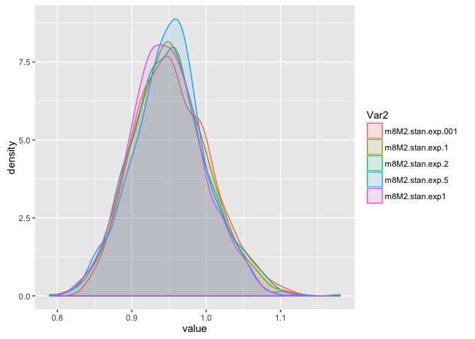

```r
fits <- ls(pattern="m8M2.stan.exp")
sigmas <- sapply(fits, function(x) extract.samples(get(x))$sigma)
colnames(sigmas) <- fits
sigmas.m <- melt(sigmas)
pl <- ggplot(sigmas.m,aes(x=value,color=Var2,fill=Var2))
pl <- pl + geom_density(alpha=0.1)
pl
```

## 8M3

Restimate a stan model at different number of warm up samples.

```r
m8m3.stan.warm1000 <- map2stan(
  alist(
    log_gdp ~ dnorm( mu , sigma ) ,
    mu <- a + bR*rugged + bA*cont_africa + bAR*rugged*cont_africa ,
    a ~ dnorm(0,100),
    bR ~ dnorm(0,10),
    bA ~ dnorm(0,10),
    bAR ~ dnorm(0,10),
    sigma ~ dcauchy(0,2)
  ), data=dd.trim )
```

[output not shown]

```
## Computing WAIC
```

```
## Constructing posterior predictions
```

```
## [ 100 / 1000 ]
[ 200 / 1000 ]
[ 300 / 1000 ]
[ 400 / 1000 ]
[ 500 / 1000 ]
[ 600 / 1000 ]
[ 700 / 1000 ]
[ 800 / 1000 ]
[ 900 / 1000 ]
[ 1000 / 1000 ]
```

```r
m8m3.stan.warm100 <- map2stan(
  alist(
    log_gdp ~ dnorm( mu , sigma ) ,
    mu <- a + bR*rugged + bA*cont_africa + bAR*rugged*cont_africa ,
    a ~ dnorm(0,100),
    bR ~ dnorm(0,10),
    bA ~ dnorm(0,10),
    bAR ~ dnorm(0,10),
    sigma ~ dcauchy(0,2)
  ), data=dd.trim, warmup = 100, iter = 1100 )
```

[output not shown]

[output not shown]

```
##                                                                                 count
## Exception thrown at line 24: normal_log: Scale parameter is 0, but must be > 0!     2
```

[output not shown]

[output not shown]

[output not shown]

[output not shown]

```
## Computing WAIC
```

```
## Constructing posterior predictions
```

```
## [ 100 / 1000 ]
[ 200 / 1000 ]
[ 300 / 1000 ]
[ 400 / 1000 ]
[ 500 / 1000 ]
[ 600 / 1000 ]
[ 700 / 1000 ]
[ 800 / 1000 ]
[ 900 / 1000 ]
[ 1000 / 1000 ]
```

```r
m8m3.stan.warm50 <- map2stan(
  alist(
    log_gdp ~ dnorm( mu , sigma ) ,
    mu <- a + bR*rugged + bA*cont_africa + bAR*rugged*cont_africa ,
    a ~ dnorm(0,100),
    bR ~ dnorm(0,10),
    bA ~ dnorm(0,10),
    bAR ~ dnorm(0,10),
    sigma ~ dcauchy(0,2)
  ), data=dd.trim, warmup = 50, iter = 1050 )
```

[output not shown]

```
## Computing WAIC
## Constructing posterior predictions
```

```
## [ 100 / 1000 ]
[ 200 / 1000 ]
[ 300 / 1000 ]
[ 400 / 1000 ]
[ 500 / 1000 ]
[ 600 / 1000 ]
[ 700 / 1000 ]
[ 800 / 1000 ]
[ 900 / 1000 ]
[ 1000 / 1000 ]
```

```r
m8m3.stan.warm10 <- map2stan(
  alist(
    log_gdp ~ dnorm( mu , sigma ) ,
    mu <- a + bR*rugged + bA*cont_africa + bAR*rugged*cont_africa ,
    a ~ dnorm(0,100),
    bR ~ dnorm(0,10),
    bA ~ dnorm(0,10),
    bAR ~ dnorm(0,10),
    sigma ~ dcauchy(0,2)
  ), data=dd.trim, warmup = 10, iter = 1010 )
```

[output not shown]

```
## Computing WAIC
## Constructing posterior predictions
```

```
## [ 100 / 1000 ]
[ 200 / 1000 ]
[ 300 / 1000 ]
[ 400 / 1000 ]
[ 500 / 1000 ]
[ 600 / 1000 ]
[ 700 / 1000 ]
[ 800 / 1000 ]
[ 900 / 1000 ]
[ 1000 / 1000 ]
```

```r
m8m3.stan.warm2 <- map2stan(
  alist(
    log_gdp ~ dnorm( mu , sigma ) ,
    mu <- a + bR*rugged + bA*cont_africa + bAR*rugged*cont_africa ,
    a ~ dnorm(0,100),
    bR ~ dnorm(0,10),
    bA ~ dnorm(0,10),
    bAR ~ dnorm(0,10),
    sigma ~ dcauchy(0,2)
  ), data=dd.trim, warmup = 2, iter = 1002 )
```

[output not shown]

```
## Computing WAIC
## Constructing posterior predictions
```

```
## [ 100 / 1000 ]
[ 200 / 1000 ]
[ 300 / 1000 ]
[ 400 / 1000 ]
[ 500 / 1000 ]
[ 600 / 1000 ]
[ 700 / 1000 ]
[ 800 / 1000 ]
[ 900 / 1000 ]
[ 1000 / 1000 ]
```

```r
precis(m8m3.stan.warm1000)
```

```
##        Mean StdDev lower 0.89 upper 0.89 n_eff Rhat
## a      9.22   0.14       8.99       9.44   274    1
## bR    -0.20   0.08      -0.32      -0.07   261    1
## bA    -1.94   0.22      -2.31      -1.59   312    1
## bAR    0.39   0.12       0.20       0.59   289    1
## sigma  0.95   0.05       0.87       1.02   534    1
```

```r
precis(m8m3.stan.warm100)
```

```
##        Mean StdDev lower 0.89 upper 0.89 n_eff Rhat
## a      9.22   0.14       9.00       9.45   272    1
## bR    -0.20   0.08      -0.33      -0.08   366    1
## bA    -1.93   0.23      -2.29      -1.56   239    1
## bAR    0.39   0.14       0.19       0.64   299    1
## sigma  0.95   0.05       0.86       1.03  1000    1
```

```r
precis(m8m3.stan.warm50)
```

```
##        Mean StdDev lower 0.89 upper 0.89 n_eff Rhat
## a      9.22   0.13       9.03       9.43   371    1
## bR    -0.20   0.07      -0.31      -0.08   517    1
## bA    -1.93   0.20      -2.20      -1.60   311    1
## bAR    0.38   0.12       0.20       0.58   374    1
## sigma  0.95   0.05       0.86       1.03  1000    1
```

```r
precis(m8m3.stan.warm10)
```

```
##        Mean StdDev lower 0.89 upper 0.89 n_eff Rhat
## a     38.73      0      38.73      38.73     1    1
## bR    -1.99      0      -1.99      -1.99     1    1
## bA    -4.42      0      -4.42      -4.42     1    1
## bAR    8.47      0       8.47       8.47     1    1
## sigma  6.85      0       6.85       6.85     1    1
```

```r
precis(m8m3.stan.warm2)
```

```
##         Mean StdDev lower 0.89 upper 0.89 n_eff Rhat
## a     -55.83      0     -55.83     -55.83     1    1
## bR    -14.56      0     -14.56     -14.56     1    1
## bA     26.00      0      26.00      26.00     1    1
## bAR    21.25      0      21.25      21.25     1    1
## sigma   1.67      0       1.67       1.67     1    1
```

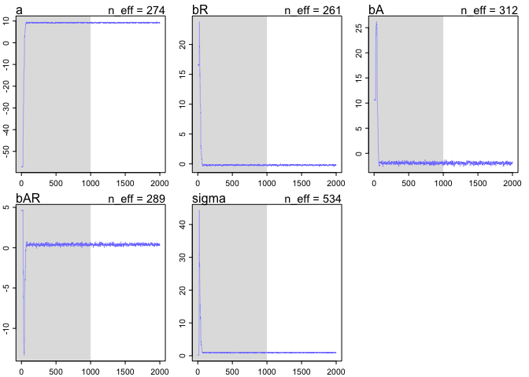

```r
plot(m8m3.stan.warm1000)
plot(m8m3.stan.warm100)
```

[figure not shown]

```r
plot(m8m3.stan.warm50)
```

[figure not shown]

```r
plot(m8m3.stan.warm10)
```

[figure not shown]

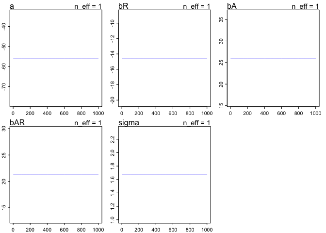

```r
plot(m8m3.stan.warm2)
```

```r
compare(m8m3.stan.warm1000,m8m3.stan.warm100,m8m3.stan.warm50,m8m3.stan.warm10,m8m3.stan.warm2)
```

```
##                        WAIC pWAIC    dWAIC weight       SE      dSE
## m8m3.stan.warm50      468.2   4.6      0.0   0.45    14.76       NA
## m8m3.stan.warm1000    468.6   4.8      0.4   0.36    14.70     0.30
## m8m3.stan.warm100     469.8   5.4      1.7   0.19    14.76     0.35
## m8m3.stan.warm10     4134.5   0.0   3666.3   0.00   122.80   123.82
## m8m3.stan.warm2    345309.3   0.0 344841.2   0.00 18414.24 18466.36
```

Things seem good with 100 warmups and even 50 but certinly not with 10 or 2; the number of effective samples drops to 1 and this is also clear from the chain traces

## 8H1

Run the model below and then inspect the posterior distubition and explain what it is accomplishing. Compare the samples for the parameters a and b. Can you explain the difference given what you know about the Cauchy distribution.

```r
mp <- map2stan(
    alist(
        a ~ dnorm(0,1),
        b ~ dcauchy(0,1)
    ),
    data=list(y=1),
    start=list(a=0,b=0),
    iter=1e4, warmup=100 , WAIC=FALSE )
```

[output not shown]

For starters this is a wierd little setup. data is define as y=1 but this is not references in a formula. I assume that the value of y does not actually matter. So I think this is just giving us the normal and Cauchy distributions for a and b. Will check…

```r
precis(mp)
```

```
##     Mean  StdDev lower 0.89 upper 0.89 n_eff Rhat
## a  -0.02    1.05      -1.67       1.67  9900 1.00
## b 360.51 2200.82      -7.67      11.09    39 1.03
```

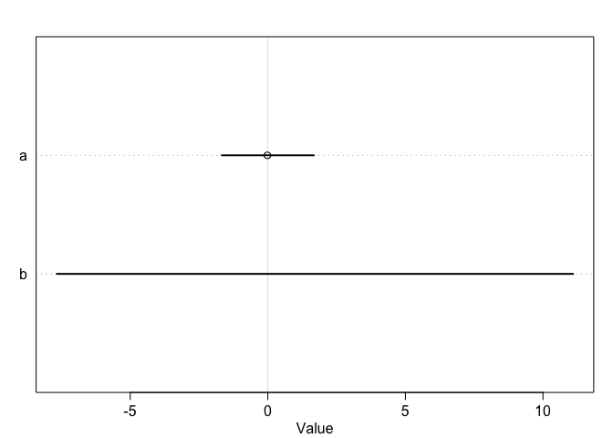

```r
plot(precis(mp))
```

Looking at the traces…

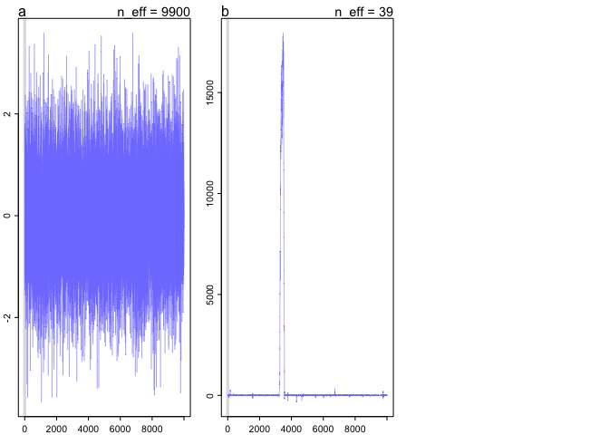

```r
plot(mp)
```

We see that the Cauchy distribution has some very extreme values. This fits of it being equivalent to the ratio of random draws from two Guassian distributions. It is easy to obtain an “extreme” value.

Compare to the respective random functions.

```r
norm.df <- melt(data.frame(posterior=extract.samples(mp)$a,
                           rnorm=rnorm(9900,0,1)))
```

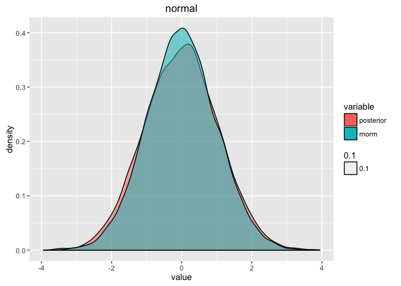

```r
qplot(x=value,fill=variable,alpha=0.1,data=norm.df,geom="density",main="normal")
```

```r
cauchy.df <- melt(data.frame(posterior=extract.samples(mp)$b,
                             rcauchy=rcauchy(9900,0,1)))
```

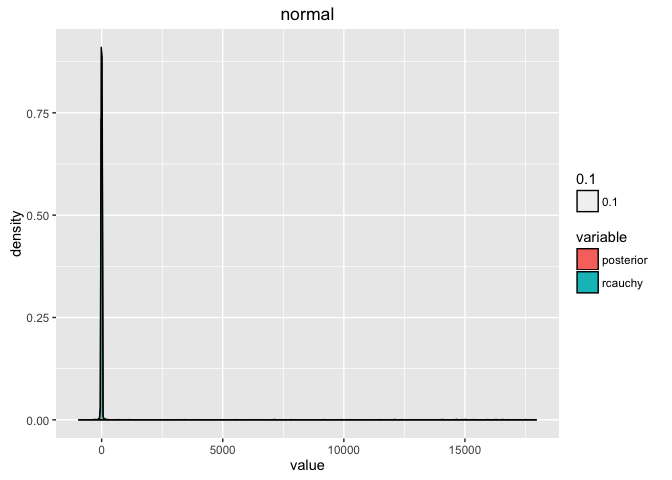

```r
qplot(x=value,fill=variable,alpha=0.1,data=cauchy.df,geom="density",main="normal")
```

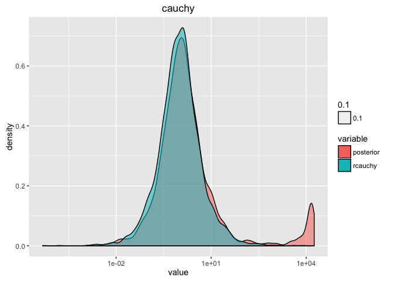

```r
qplot(x=value,fill=variable,alpha=0.1,data=cauchy.df,geom="density",main="cauchy") + scale_x_log10()
```

Note that the last plot is not really correct; samples near 0 were dropped due to the log transformation.

## 8H2

Recall the Divorce Rate data set. Repeat the analyses of models 5.1, 5.2, and 5.3, but with map2stan. Use compare to compare the fits on WAIC. Explain.

```r
data(WaffleDivorce)
d <- WaffleDivorce
# standardize predictor
d$MedianAgeMarriage.s <- (d$MedianAgeMarriage-mean(d$MedianAgeMarriage))/
  sd(d$MedianAgeMarriage)
  d$Marriage.s <- (d$Marriage - mean(d$Marriage))/sd(d$Marriage)
```

fit model map models

```r
m5.1 <- map(
  alist(
    Divorce ~ dnorm( mu , sigma ) ,
    mu <- a + bA * MedianAgeMarriage.s ,
    a ~ dnorm( 10 , 10 ) ,
    bA ~ dnorm( 0 , 1 ) ,
    sigma ~ dunif( 0 , 10 )
  ) , data = d )

m5.2 <- map(
  alist(
    Divorce ~ dnorm( mu , sigma ) ,
    mu <- a + bR * Marriage.s ,
    a ~ dnorm( 10 , 10 ) ,
    bR ~ dnorm( 0 , 1 ) ,
    sigma ~ dunif( 0 , 10 )
  ) , data = d )

m5.3 <- map(
  alist(
    Divorce ~ dnorm( mu , sigma ) ,
    mu <- a + bR*Marriage.s + bA*MedianAgeMarriage.s ,
    a ~ dnorm( 10 , 10 ) ,
    bR ~ dnorm( 0 , 1 ) ,
    bA ~ dnorm( 0 , 1 ) ,
    sigma ~ dunif( 0 , 10 )
  ),
  data = d )
```

fit stan models

```r
m5.1.stan <- map2stan(
  alist(
    Divorce ~ dnorm( mu , sigma ) ,
    mu <- a + bA * MedianAgeMarriage.s ,
    a ~ dnorm( 10 , 10 ) ,
    bA ~ dnorm( 0 , 1 ) ,
    sigma ~ dunif( 0 , 10 )
  ) , data = d, chains=4 )
```

[output not shown]

[output cut: 16 more lines]

[output not shown]

```
##
## WARNING: No variance estimation is
##          performed for num_warmup < 20
##
##
## Chain 1, Iteration: 1 / 1 [100%]  (Sampling)
##  Elapsed Time: 3e-06 seconds (Warm-up)
##                2.6e-05 seconds (Sampling)
##                2.9e-05 seconds (Total)
```

```
## Computing WAIC
```

```
## Constructing posterior predictions
```

```
## [ 400 / 4000 ]
[ 800 / 4000 ]
[ 1200 / 4000 ]
[ 1600 / 4000 ]
[ 2000 / 4000 ]
[ 2400 / 4000 ]
[ 2800 / 4000 ]
[ 3200 / 4000 ]
[ 3600 / 4000 ]
[ 4000 / 4000 ]
```

```r
m5.2.stan <- map2stan(
  alist(
    Divorce ~ dnorm( mu , sigma ) ,
    mu <- a + bR * Marriage.s ,
    a ~ dnorm( 10 , 10 ) ,
    bR ~ dnorm( 0 , 1 ) ,
    sigma ~ dunif( 0 , 10 )
  ) , data = d, chains=4 )
```

[output not shown]

[output cut: 16 more lines]

[output not shown]

```
##
## WARNING: No variance estimation is
##          performed for num_warmup < 20
##
##
## Chain 1, Iteration: 1 / 1 [100%]  (Sampling)
##  Elapsed Time: 4e-06 seconds (Warm-up)
##                0.000142 seconds (Sampling)
##                0.000146 seconds (Total)
```

```
## Computing WAIC
```

```
## Constructing posterior predictions
```

```
## [ 400 / 4000 ]
[ 800 / 4000 ]
[ 1200 / 4000 ]
[ 1600 / 4000 ]
[ 2000 / 4000 ]
[ 2400 / 4000 ]
[ 2800 / 4000 ]
[ 3200 / 4000 ]
[ 3600 / 4000 ]
[ 4000 / 4000 ]
```

```r
m5.3.stan <- map2stan(
  alist(
    Divorce ~ dnorm( mu , sigma ) ,
    mu <- a + bR*Marriage.s + bA*MedianAgeMarriage.s ,
    a ~ dnorm( 10 , 10 ) ,
    bR ~ dnorm( 0 , 1 ) ,
    bA ~ dnorm( 0 , 1 ) ,
    sigma ~ dunif( 0 , 10 )
  ),
  data = d,chains=4 )
```

[output not shown]

[output cut: 16 more lines]

[output not shown]

```
##
## WARNING: No variance estimation is
##          performed for num_warmup < 20
##
##
## Chain 1, Iteration: 1 / 1 [100%]  (Sampling)
##  Elapsed Time: 3e-06 seconds (Warm-up)
##                2.8e-05 seconds (Sampling)
##                3.1e-05 seconds (Total)
```

```
## Computing WAIC
```

```
## Constructing posterior predictions
```

```
## [ 400 / 4000 ]
[ 800 / 4000 ]
[ 1200 / 4000 ]
[ 1600 / 4000 ]
[ 2000 / 4000 ]
[ 2400 / 4000 ]
[ 2800 / 4000 ]
[ 3200 / 4000 ]
[ 3600 / 4000 ]
[ 4000 / 4000 ]
```

Not clear if the problem asks us to compare from stan to map or to compare within each engine type. Do both.

map vs stan

```r
compare(m5.1,m5.1.stan)
```

```
##            WAIC pWAIC dWAIC weight    SE  dSE
## m5.1.stan 186.6   4.0   0.0   0.58 12.42   NA
## m5.1      187.3   4.6   0.7   0.42 14.06 1.66
```

```r
compare(m5.2,m5.2.stan)
```

```
##            WAIC pWAIC dWAIC weight    SE  dSE
## m5.2.stan 200.6   3.5   0.0   0.52  9.58   NA
## m5.2      200.8   3.9   0.2   0.48 10.92 1.37
```

```r
compare(m5.3,m5.3.stan)
```

```
##            WAIC pWAIC dWAIC weight    SE  dSE
## m5.3.stan 187.9   4.8   0.0   0.67 12.44   NA
## m5.3      189.3   5.8   1.4   0.33 14.46 2.08
```

different models

```r
compare(m5.1,m5.2,m5.3)
```

```
##       WAIC pWAIC dWAIC weight    SE   dSE
## m5.1 187.7   4.8   0.0   0.79 14.34    NA
## m5.3 190.4   6.5   2.7   0.21 15.07  1.13
## m5.2 201.0   4.0  13.3   0.00 10.92 10.60
```

```r
compare(m5.1.stan,m5.2.stan,m5.3.stan)
```

```
##            WAIC pWAIC dWAIC weight    SE  dSE
## m5.1.stan 186.6   4.0   0.0   0.65 12.42   NA
## m5.3.stan 187.9   4.8   1.2   0.35 12.44 0.77
## m5.2.stan 200.6   3.5  14.0   0.00  9.58 9.16
```

Either way the fits and conclusions are pretty comparable. Is this what the point was?

## 8H3

Sometimes changes a prior for one parameter has unanticipated effects on other parameters. This can occur when the parameters are highly correlated in the posterior. Work and think through the following example.

Simulate leg length and height for 100 individuals

```r
N <- 100
height <- rnorm(N,10,2)
leg_prop <- runif(N,0.4,0.5)
leg_left <- leg_prop*height +
    rnorm( N , 0 , 0.02 )
leg_right <- leg_prop*height +
    rnorm( N , 0 , 0.02 )
d <- data.frame(height,leg_left,leg_right)
```

Original priors, now fit with Stan

```r
m5.8s <- map2stan(
    alist(
        height ~ dnorm( mu , sigma ) ,
        mu <- a + bl*leg_left + br*leg_right ,
        a ~ dnorm( 10 , 100 ) ,
        bl ~ dnorm( 2 , 10 ) ,
        br ~ dnorm( 2 , 10 ) ,
        sigma ~ dcauchy( 0 , 1 )
),
data=d, chains=4, start=list(a=10,bl=0,br=0,sigma=1) )
```

[output not shown]

[output cut: 26 more lines]

[output not shown]

```
## Computing WAIC
```

```
## Constructing posterior predictions
```

```
## [ 400 / 4000 ]
[ 800 / 4000 ]
[ 1200 / 4000 ]
[ 1600 / 4000 ]
[ 2000 / 4000 ]
[ 2400 / 4000 ]
[ 2800 / 4000 ]
[ 3200 / 4000 ]
[ 3600 / 4000 ]
[ 4000 / 4000 ]
```

Change prior for bR so that it is alway positive:

```r
m5.8s2 <- map2stan(
    alist(
        height ~ dnorm( mu , sigma ) ,
        mu <- a + bl*leg_left + br*leg_right ,
        a ~ dnorm( 10 , 100 ) ,
        bl ~ dnorm( 2 , 10 ) ,
        br ~ dnorm( 2 , 10 ) & T[0,] ,
        sigma ~ dcauchy( 0 , 1 )
),
data=d, chains=4, start=list(a=10,bl=0,br=0,sigma=1) )
```

[output not shown]

[output cut: 26 more lines]

[output not shown]

```
## Computing WAIC
```

```
## Constructing posterior predictions
```

```
## [ 400 / 4000 ]
[ 800 / 4000 ]
[ 1200 / 4000 ]
[ 1600 / 4000 ]
[ 2000 / 4000 ]
[ 2400 / 4000 ]
[ 2800 / 4000 ]
[ 3200 / 4000 ]
[ 3600 / 4000 ]
[ 4000 / 4000 ]
```

```
## Warning in map2stan(alist(height ~ dnorm(mu, sigma), mu <- a + bl * leg_left + : There were 1581 divergent iterations during sampling.
## Check the chains (trace plots, n_eff, Rhat) carefully to ensure they are valid.
```

A bunch of warnings for m5.8s2…

Take a look

```r
precis(m5.8s)
```

```
##        Mean StdDev lower 0.89 upper 0.89 n_eff Rhat
## a      1.12   0.32       0.62       1.63  1915    1
## bl     2.90   2.62      -1.04       7.24  1484    1
## br    -0.92   2.62      -5.27       2.99  1481    1
## sigma  0.66   0.05       0.58       0.73  1831    1
```

```r
precis(m5.8s2)
```

```
##       Mean StdDev lower 0.89 upper 0.89 n_eff Rhat
## a     1.09   0.32       0.52       1.54   757 1.00
## bl    0.16   1.48      -1.64       2.04   254 1.02
## br    1.84   1.48       0.01       3.66   252 1.02
## sigma 0.66   0.05       0.58       0.73   666 1.00
```

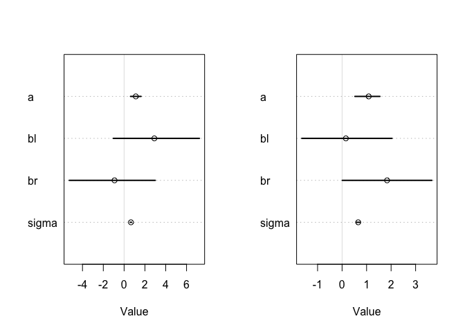

```r
op <- par(mfrow=c(1,2))
plot(precis(m5.8s))
plot(precis(m5.8s2))
```

```r
par(op)
```

more diagnostics

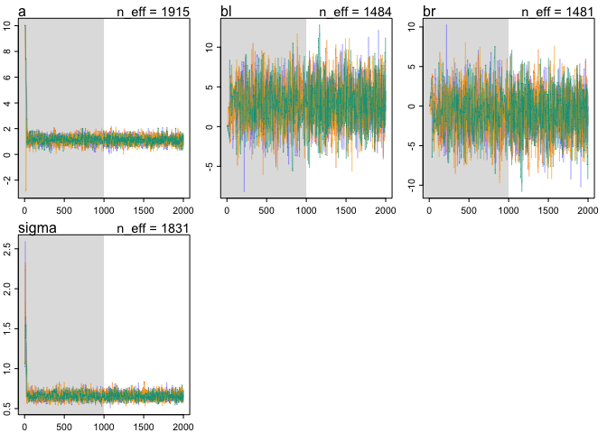

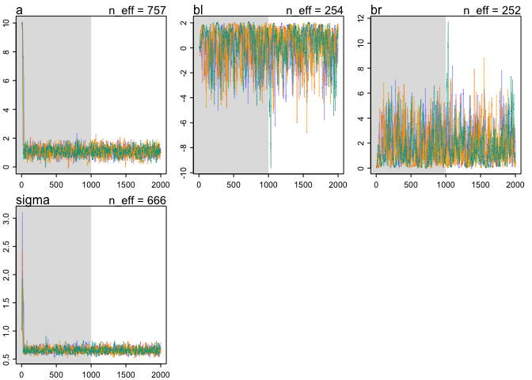

```r
plot(m5.8s)
plot(m5.8s2)
```

Here it is more clear that the fits are behaving differently, with the posterior sampleing bR and bL differently in the second version.

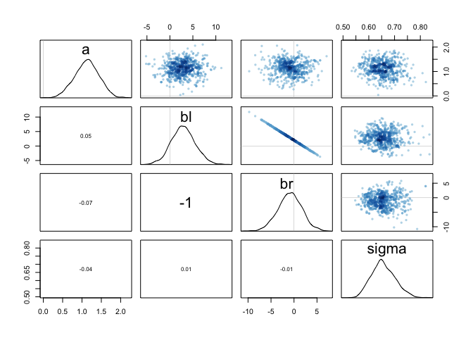

```r
pairs(m5.8s)
```

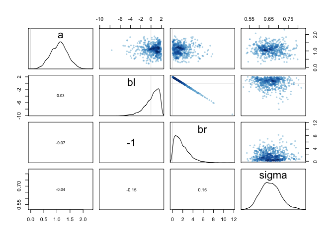

```r
pairs(m5.8s2)
```

This shows that the posterior for bl and br are skewed in the second fit but not in the first.

Comparing the distributions…

```r
post.df <- melt(data.frame(bl.m1=extract.samples(m5.8s)$bl,
                           br.m1=extract.samples(m5.8s)$br,
                           bl.m2=extract.samples(m5.8s2)$bl,
                           br.m2=extract.samples(m5.8s2)$br))
```

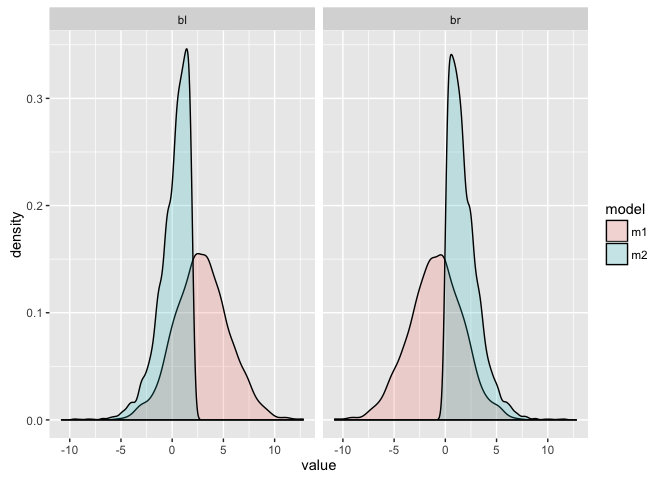

```r
post.df$model=substr(post.df$variable,4,5)
post.df$parameter=substr(post.df$variable,1,2)
pl <- ggplot(post.df,aes(x=value,fill=model))
pl <- pl + geom_density(alpha=0.2)
pl <- pl + facet_wrap(~ parameter,ncol=2)
pl
```

## 8H4

Use DIC or WAIC to compare the effective parameters.

```r
compare(m5.8s,m5.8s2)
```

```
##         WAIC pWAIC dWAIC weight    SE  dSE
## m5.8s  201.7   3.4   0.0   0.56 10.99   NA
## m5.8s2 202.1   3.0   0.4   0.44 11.50 2.02
```

```r
compare(m5.8s,m5.8s2,func=DIC)
```

```
##          DIC  pD dDIC weight
## m5.8s  202.0 3.8  0.0   0.56
## m5.8s2 202.4 3.4  0.4   0.44
```

By both WAIC and DIC the model with the constrained bR has a somewhat smaller number of parameters. Would we really expect this to be the case? In both cases they are completely correlated so should only really be 1 parameter. But it muse be that since now they are constrained they are sampling yet less space.